# Logistic Regression, Prediction and ROC

The objective of this case is to get you understand logistic regression (binary classification) and some important ideas such as cross validation, ROC curve, cut-off probability. Code in this case is built upon lecture slides and Shaonan Tian’s sample code.

## Input and sample data

First load the credit scoring data. It is easy to load comma-separated values (CSV).

```r
credit.data <- read.csv("http://homepages.uc.edu/~maifg/7040/credit0.csv", header=T)
```

Now split the data 90/10 as training/testing datasets:

```r
id_train <- sample(nrow(credit.data),nrow(credit.data)*0.90)
credit.train = credit.data[id_train,]
credit.test = credit.data[-id_train,]
```

The training dataset has 63 variables, 4500 obs.

```r
colnames(credit.train)
```

```
##  [1] "id"     "Y"      "X2"     "X3"     "X4"     "X5"     "X6"
##  [8] "X7"     "X8"     "X9"     "X10_2"  "X11_2"  "X12_2"  "X13_2"
## [15] "X14_2"  "X15_2"  "X15_3"  "X15_4"  "X15_5"  "X15_6"  "X16_2"
## [22] "X16_3"  "X16_4"  "X16_5"  "X16_6"  "X17_2"  "X17_3"  "X17_4"
## [29] "X17_5"  "X17_6"  "X18_2"  "X18_3"  "X18_4"  "X18_5"  "X18_6"
## [36] "X18_7"  "X19_2"  "X19_3"  "X19_4"  "X19_5"  "X19_6"  "X19_7"
## [43] "X19_8"  "X19_9"  "X19_10" "X20_2"  "X20_3"  "X20_4"  "X21_2"
## [50] "X21_3"  "X22_2"  "X22_3"  "X22_4"  "X22_5"  "X22_6"  "X22_7"
## [57] "X22_8"  "X22_9"  "X22_10" "X22_11" "X23_2"  "X23_3"  "X24_2"
```

## Logistic Regression

Let’s build a logistic regression model based on all X variables. Note id is excluded from the model.

```r
credit.glm0<-glm(Y~.-id,family=binomial,credit.train);
```

You can view the result of the estimation:

```r
summary(credit.glm0)
```

Note that there might be a warning message “*Warning: glm.fit: fitted probabilities numerically 0 or 1 occurred*”. This happens because of a problem called quasi-complete separation. You can [learn more here](http://www.ats.ucla.edu/stat/mult_pkg/faq/general/complete_separation_logit_models.htm) or [here](http://support.sas.com/kb/22/599.html). The offending variable is *X9*. We will choose to ignore the warning now. You can try fitting your model without *X9*.

You can simply extract some criteria of the model fitting, for example, Residual deviance (equivalent to SSE in linear regression model), AIC and BIC. Unlike linear regression models, there is no $R^2$ in logistic regression.

```r
credit.glm0$deviance
```

```
## [1] 1600.637
```

```r
AIC(credit.glm0)
```

```
## [1] 1724.637
```

```r
BIC(credit.glm0)
```

```
## [1] 2122.171
```

### Variable selection

We can use the same procedures of variable selection, i.e. forward, backward, and stepwise, for linear regression models. **caution: this will take a very long time since there are too many variables here**.

```r
credit.glm.step <- step(credit.glm0)
```

Or you can try model selection with BIC:

```r
credit.glm.step <- step(credit.glm0, k=log(nrow(credit.train)))
```

**Exercise:** Try forward and backward selection procedures to see if they delivers the same best model.

## Prediction Using Logistic Regression

### Predicted probability

Recall the lecture, the prediction outcome of logistic regression is a probability, i.e., $P(Y=1|\mathbf(X))$. However, different threshold (cut-off probability) results in different classification.

To get predicted probability, we will use the same function as in linear regression, `predict()`. The only thing different is that we must specify one more argument in the function: **type=“response”**. Otherwise, the outcome will be the linear predictor $\eta$ (can be any value) instead of probability.

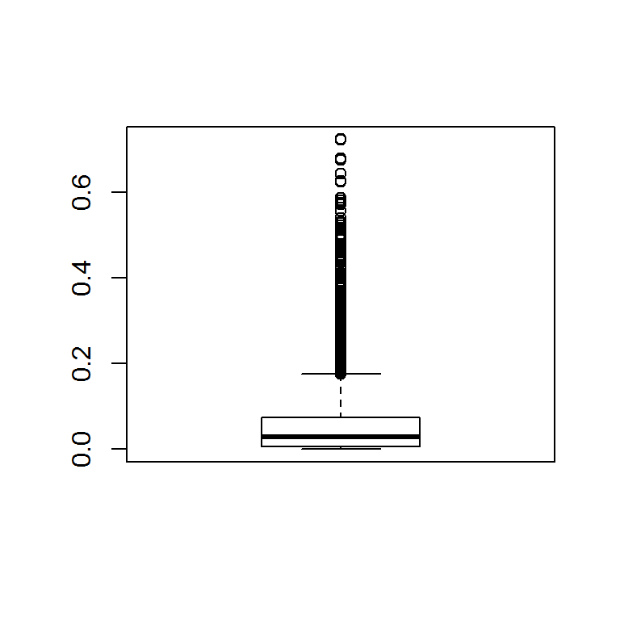

```r
pred.glm0<- predict(credit.glm0, newdata=credit.train, type="response")
boxplot(pred.glm0)
```

For in-sample prediction, you omit the second argument “newdata=credit.train”. **But this is not the case for out-of-sample prediction.**

### Binary classification

Eventually, you want a binary classification decision rule. Recall that the classification outcome depends on the threshold value (cut-off probabiliry).

These tables illustrate the impact of choosing different cut-off probability. Choosing a large cut-off probability will result in few cases being predicted as 1, and chossing a small cut-off probability will result in many cases being predicted as 1.

```r
table((pred.glm0 > 0.5)*1)
```

```
##
##    0    1
## 4477   23
```

```r
table((pred.glm0 > 0.2)*1)
```

```
##
##    0    1
## 4194  306
```

```r
table((pred.glm0 > 0.0001)*1)
```

```
##
##    0    1
##  500 4000
```

Therefore, determine the optimal cut-off probability is crucial. The simplest way to determine the cut-off is to use the proportion of “1” in the original data. We will intriduce a more appropriate way to determine the optimal p-cut.

### Determine cut-off probability for classification

The simplest way is to choose the event proportion in training sample. This is reasonable because the sample proportion is an estimate of mean probability of $Y=1$.

```r
pcut1<- mean(credit.train$Y)
```

Based on this cut-off probability, we can obtain the binary prediction (predicted classification) and the confusion matrix

```r
# get binary prediction
class.glm0<- (pred.glm0>pcut1)*1
# get confusion matrix
table(credit.train$Y, class.glm0, dnn = c("True", "Predicted"))
```

```
##     Predicted
## True    0    1
##    0 3041 1190
##    1   62  207
```

Then it is easy to get different types of classification error rate, i.e., false positive rate (FPR), false negative rate (FNR), and overall misclassification rate (MR). **Commonly, you can use overall MR as the cost (a criterion) to evaluate the model prediction.**

```r
# (equal-weighted) misclassification rate
MR<- mean(credit.train$Y!=class.glm0)
# False positive rate
FPR<- sum(credit.train$Y==0 & class.glm0==1)/sum(credit.train$Y==0)
# False negative rate (exercise)
FNR<-
```

### Determine Optimal cut-off Probability using Grid Search Method

Recall the lecture, different p-cut results in different confusion matrix, hence different MR (or cost). You need to search all possible p-cut to find the one that provides minimum cost. The first step is to define a symmetric/asymmetric cost function (misclassification rate), as a function of cut-off. Think about what else is needed to calculate MR? The answer is observed $Y$ and predicted probability.

```r
# define a cost function with input "obs" being observed response
# and "pi" being predicted probability, and "pcut" being the threshold.
costfunc = function(obs, pred.p, pcut){
    weight1 = 10   # define the weight for "true=1 but pred=0" (FN)
    weight0 = 1    # define the weight for "true=0 but pred=1" (FP)
    c1 = (obs==1)&(pred.p<pcut)    # count for "true=1 but pred=0"   (FN)
    c0 = (obs==0)&(pred.p>=pcut)   # count for "true=0 but pred=1"   (FP)
    cost = mean(weight1*c1 + weight0*c0)  # misclassification with weight
    return(cost) # you have to return to a value when you write R functions
} # end of the function
```

Next, define a sequence of probability (you need to search the optimal p-cut from this sequence)

```r
# define a sequence from 0.01 to 1 by 0.01
p.seq = seq(0.01, 1, 0.01)
```

Then, you need to calculate the cost (as you defined before) for each probability in the sequence p.seq.

```r
# write a loop for all p-cut to see which one provides the smallest cost
# first, need to define a 0 vector in order to save the value of cost from all pcut
cost = rep(0, length(p.seq))
for(i in 1:length(p.seq)){
    cost[i] = costfunc(obs = credit.train$Y, pred.p = pred.glm0, pcut = p.seq[i])
} # end of the loop
```

Last, draw a plot with cost against p.seq, and find the p-cut that gives you the minimum cost.

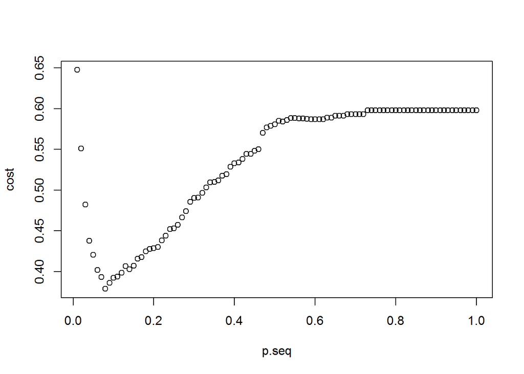

```r
# draw a plot with X axis being all pcut and Y axis being associated cost
plot(p.seq, cost)
```

```r
# find the optimal pcut
optimal.pcut.glm0 = p.seq[which(cost==min(cost))]
```

**Exercise:** (1) obtain confusion matrix and calculate the (asymmetric) cost based on the optimal cut-off. (2) Find optimal cut-off probability using symmetric cost. Further, rewrite the cost function to make the weights (or the ratio of two weights) as input parameter.

## ROC Curve

We introduce two packages to get ROC curve and AUC. To get the ROC curve you need to install the verification library.

```r
install.packages('verification')
```

To plot the ROC curve, the first argument of roc.plot is the vector with actual values “A binary observation (coded {0, 1 } )”. The second argument is the vector with predicted probability.

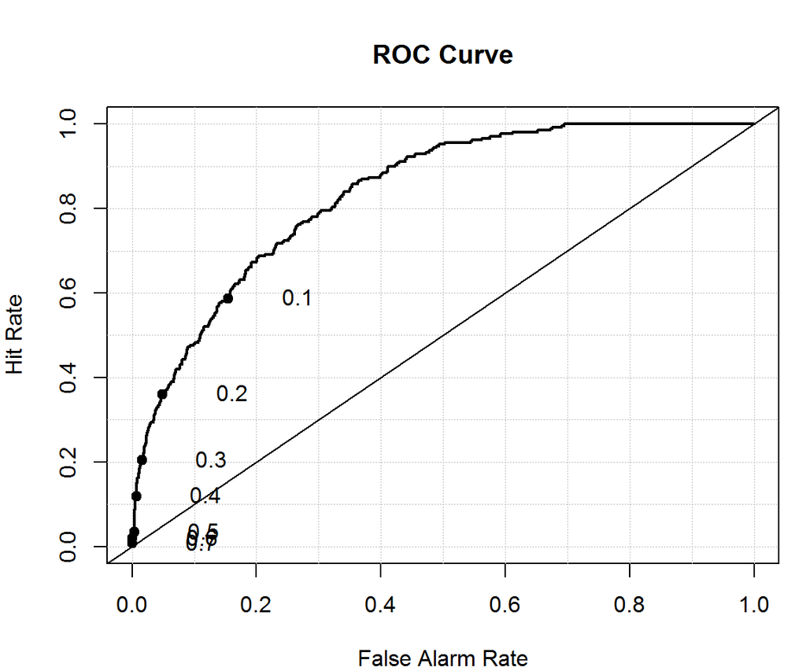

```
##      Model      Area      p.value binorm.area
## 1 Model  1 0.8356185 1.288206e-76          NA
```

```r
roc.plot(credit.train$Y == '1', pred.glm0)$roc.vol
```

Another library [ROCR](http://rocr.bioinf.mpi-sb.mpg.de/) can also generate ROC curves for you.

```r
install.packages('ROCR')
```

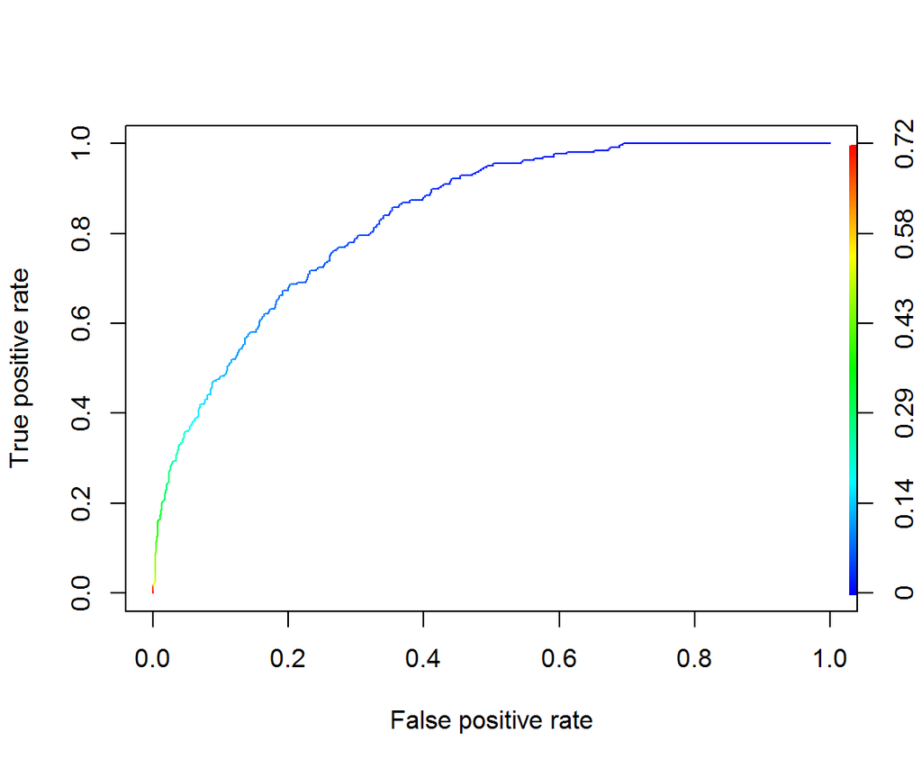

```r
library(ROCR)
pred <- prediction(pred.glm0, credit.train$Y)
perf <- performance(pred, "tpr", "fpr")
plot(perf, colorize=TRUE)
```

```r
#Get the AUC
unlist(slot(performance(pred, "auc"), "y.values"))
```

```
## [1] 0.8356185
```

## Out-of-sample performance

**Exercise 1:** Obtain the confusion matrix and calculate the cost for the testing sample based on (1) naive cut-off determined by sample proportion; (2) optimal cut-off determined by asymmetric cost; (3) optimal cut-off determined by symmetric cost.

**Exercise 2:** Draw the ROC curve and obtain AUC for testing sample.

*Hint:* start with getting the predicted probability of testing sample.

```r
pred.glm0.test<-
```

### Cross validation

Refer to lecture slides and Elements of Statistical Learning book (section 7.10) for more advice on cross validation. You should read the cv.glm help to understand how it works. We can use the same cost function as defined before, but you need to modify it such that there are only two input: observed $Y$ and predicted probability.

```r
costfunc = function(obs, pred.p){
    weight1 = 10   # define the weight for "true=1 but pred=0" (FN)
    weight0 = 1    # define the weight for "true=0 but pred=1" (FP)
    c1 = (obs==1)&(pred.p<pcut)    # count for "true=1 but pred=0"   (FN)
    c0 = (obs==0)&(pred.p>=pcut)   # count for "true=0 but pred=1"   (FP)
    cost = mean(weight1*c1 + weight0*c0)  # misclassification with weight
    return(cost) # you have to return to a value when you write R functions
} # end of the function
```

Then you need to assign a value to pcut.

```r
pcut = optimal.pcut.glm0
```

10-fold cross validation, note you should use the **full data** for cross-validation.

```r
library(boot)
credit.glm1<-glm(Y~.-id,family=binomial,credit.data);
cv.result = cv.glm(data=credit.data, glmfit=credit.glm1, cost=costfunc, K=10)
cv.result$delta[2]
```

```
## [1] 0.42166
```

## Search for optimal cut-off probability by cross validation.

Cross-validation is a very useful tool to choose tuning parameters (here we consider the p-cut as tuning parameter for classification). Here we demonstrate this idea. Basically, you want to choose a cut-off probability such that it minimizes the out-of-sample classification cost (MR). Instead of minimizing the cost of a single testing sample, we minimize the average cost (CV score) of multiple testing samples, and find the optimal cut-off corresponding to smallest CV score.

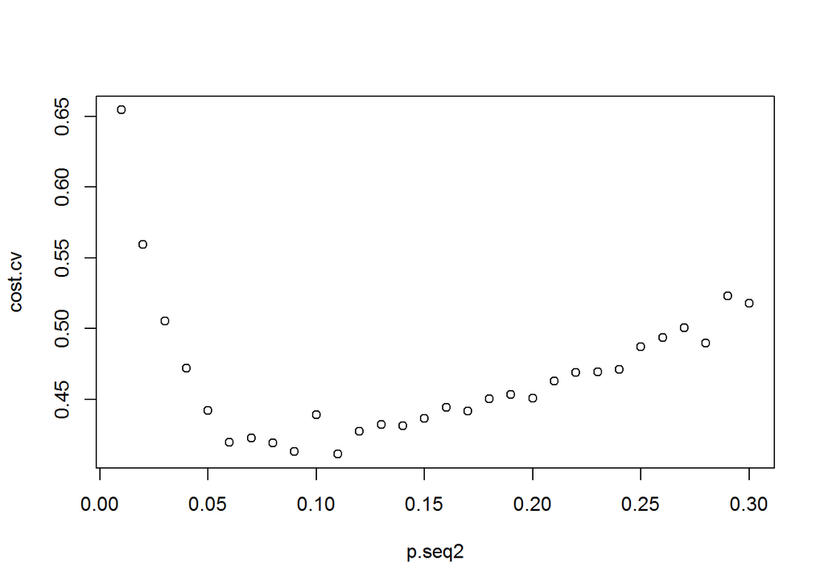

```r
# define a narrow sequence of p-cut
p.seq2<- seq(0.01,0.3,0.01)
# use the same cost function as you have defined before
# the only difference is the searching procedure
# write a loop for all p-cut to see which one provides the smallest cost from cv.glm()
cost.cv = rep(0, length(p.seq2))  # define a 0 vector in order to save the value of cost from all pcut
for(i in 1:length(p.seq2)){
    pcut = p.seq2[i]
    # use cv.glm() to give you the cv score, which is the cost as you defined
    cost.cv[i] = cv.glm(data= credit.data, glmfit= credit.glm1, cost = costfunc, K=3)$delta[2]
} # end of the loop
# draw a plot with X axis being all pcut and Y axis being associated cost
plot(p.seq2, cost.cv)
```

```r
# find the optimal pcut
optimal.pcut.cv = p.seq2[which(cost.cv==min(cost.cv))]
```

**Exercise:** Using the optimal cut-off determined by CV to obtain confusion matrix and calculate the asymmetric cost.

Note that if you use asymmetric cost to find optimal cut-off, then you should calculate the asymmetric cost (MR) for comparison. Keep consistent!

## Starter code for German credit scoring

Refer to http://archive.ics.uci.edu/ml/datasets/Statlog+(German+Credit+Data) for variable description. Notice that “It is worse to class a customer as good when they are bad (5), than it is to class a customer as bad when they are good (1).” Define your cost function accordingly!

```r
german_credit = read.table("http://archive.ics.uci.edu/ml/machine-learning-databases/statlog/german/german.data")

colnames(german_credit)=c("chk_acct","duration","credit_his","purpose","amount","saving_acct","present_emp","installment_rate","sex","other_debtor","present_resid","property","age","other_install","housing","n_credits","job","n_people","telephone","foreign","response")

#orginal response coding 1= good, 2 = bad
#we need 0 = good, 1 = bad
german_credit$response = german_credit$response - 1
```